# Leyes y Armas: Un estudio empírico de la relación entre los tiroteos masivos, la proporción de habitantes armados y los controles legales a las armas

Oscar Rosales Corzo, David Alvarez, Arturo Sananez, Santiago Bonadies

2022-07-15

# Introducción

## Descripción del Tema a Abordar

El siguiente trabajo pretende aproximarnos al fenomeno de los Tiroteos Masivos, situación debastadora que destruye realidades en cuestión de segundos. Para esto, nos suscribimos a la definición dada por el Gun Violence Archive (GVA), una organización sin fines de lucro que cataloga cada incidente de violencia armada en los Estados Unidos. Con lo que, el GVA define como Tiroteo Masivo a los eventos en los cuales hay “un mínimo de 4 victimas disparadas, ya sea heridas o muertas, sin incluir al pistolero quien pudo haber resultado muerto o herido en el incidente.”(Gun Violence Archive, p.1)

## Motivación

Nuestra inspiración va hacia entender un poco más esta compliada discusión sobre los tiroteos masivos. Esto desde las herramientas que nos brinda la estadística, ya que creemos que nos ayudará a tener una visión basada en hechos del fenonemo, en lugar de las usuales posturas atadas a ideologias o emociones.

## Justificación

En la lista de asuntos divisivos y politizados en Estados Unidos nos encontramos con temas variados como lo son: El Aborto, Las Vacunas (en el contexto de la crisis del COVID-19), los temas relacionados con la comunidad LGBT, entre muchos otros. De todos estos, el tema del control de armas es uno que llama la atención por varios motivos.

Con lo que se hace verdaderamente alarmante los niveles de violencia que atraviesa el país, ya que al comparar a Estados Unidos con otras naciones industrializadas es fácil darse cuenta de que hay un problema que atender debido a que “las muertes relacionadas con armas son altas en países como El Salvador, Guatemala y Colombia, donde las pandillas y el tráfico de drogas son significativos. Entre economías desarrolladas, nadie tiene tantas muertes violentas con armas como EE.UU.” (Sam y Rupp, 2022, p.3). Por otro lado, otro punto que llama la atención es que “Estados Unidos tiene más armas per cápita que cualquier otro país del mundo” (Frank Newport, 2021, p.13). Todo lo anterior, mezclado con una profunda frustración y deseo que se implementen acciones, lo cual se ve reflejado en que “las encuestas consistentemente muestran que los estadounidenses creen que los controles de armas actuales no son suficientemente restrictivos, y soluciones básicas como revisión de antecedentes tienen apoyo de demócratas como republicanos” (Zara, 2022, p.3). Con lo cual, es inevitable cuestionarse qué factores juegan en que haya situaciones como tales como los sucesos del “14 de diciembre de 2012, seis adultos y 20 niños murieron por los disparos que hizo Adam Lanza, quien antes había matado a su madre, Nancy Lanza, en su casa” (CNN, 2022, p.1).

## Interrogantes a Evaluar

Este es un trabajo que pretende ser una replica del paper “State gun laws, gun ownership, and mass shootings in the US: cross sectional time series” desarrollado por Reeping y compañia. Con lo que nos planteamos interrograntes similares a las que ellos se hicieron, las cuales son:

- ¿Cuál es la relación que hay entre las leyes de posesión de armas en los diferentes Estados de Estados Unidos y la cantidad de Tiroteos Masivos?
- ¿Cuál es la relación que hay entre la proporción de habitantes con armas de fuego y los Tiroteos Masivos?

# Metodología

## Descrición de los Datos Utilizados

Para resolver estas preguntas planeamos usar un set de datos compuestos principalmente por:

- Número de Tiroteos Masivos
- Año
- Ubicación de los Tiroteos (Estado)
- Número de Muertos
- Número de Heridos
- Derecho Al Porte de Armas (Índice que mide que coste directo que tienen las leyes de control de armas sobre los dueños de armas y negocios relacionados con las armas)
- Proporción de Habitantes Armados (Medido como porcentaje de suicidios cometidos con armas de fuego)
- Mediana de ingresos de los hogares
- Porcentaje de pobreza
- Porcentaje de desempleo

Estos datos pueden ser colectados principalmente de 4 fuentes, las cuales son:

- The Gun Violence Archive
- The Centers for Disease Control and Prevention’s online database, WONDER
- The United States Census Bureau
- Freedom in the 50 States Report made by Cato Institute

Cabe destacar, que usamos porcentaje de suicidios cometidos con armas de fuego como proxy de proporción de habitantes armados debido a que “Una revisón de sobre 24 indicadores de posesión de armas encontró que suicidios cometidos con armas de fuego era la mejor medida para estimar poseción de armas por Estado” (Reeping et al, 2019, p.2). Así mismo, el periodo de tiempo el cual analizará el modelo será durante 2014-2019. Sin embargo, puede que algunas gráficas en el análisis exploratorio usen data que pueda abarcar hasta el 2021, esto con el objetivo de entender un poco más la realidad de los datos.

### Tabla Descriptiva de los Datos

```r
stargazer(as.data.frame(consolidado), type = "text")
```

```
##
## ==========================================================================
## Statistic                N      Mean        St. Dev.      Min      Max
## --------------------------------------------------------------------------
## Incident_Count          228     8.890         9.133        1        46
## Gun_Rights              228     0.006         0.025     -0.055    0.044
## Median_Household_Income 228  61,071.490    10,394.490   42,900    86,700
## Over_All_Poverty        228    14.484         3.115      9.000    24.100
## firearm_Rate            228    47.760        12.187      8.850    71.734
## Unemployment_Rate       228     5.270         1.461      2.500    9.800
## Population              228 8,047,499.000 7,601,857.000 578,759 39,512,223
## --------------------------------------------------------------------------
```

# Metodología a Utilizar

Nos planteamos realizar un modelo de datos panel, el cual tendrá como dimensión transversal estados y años como la dimensión de línea de tiempo. Esto, nos permitirá entender la relación que hay entre la regulación de las armas y los tiroteos masivos, a través de los diferentes estados y los diferentes años. Lo cual, hace que esta metodología sea perfecta para responder a las interrogantes iniciales. Cabe mencionar, que principalemente escogimos este tipo de modelo porque es el usado por nuestro trabajo guia. Pero, de los diferentes modelos de datos panel escogemos el de efectos aleatorios debido a que una prueba hausman nos indica que es lo mejor.

# Análisis

## Análisis Exploratorio

Una revisión inicial de los datos del GVA nos permite comentar algunas cosas, primero que nada, como lo muestra el siguiente gráfico, la cantidad de Tiroteos Masivos ha venido aumentado en los años 2020 y 2021.

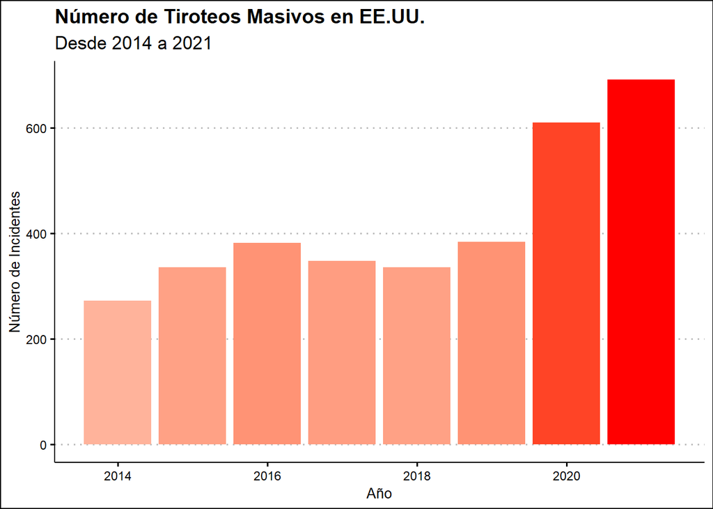

```r
chart1 <- all_gva %>%
  #filter(Year %in% anos_validos) %>%
  group_by(Year) %>%
  summarise(Incident_Count = length(Incident_ID)) %>%
  ggplot() +
  geom_col(aes(Year,Incident_Count, fill = Incident_Count)) +
  scale_fill_gradient2( low = "white", high = "red" )+
  theme_clean() +
  theme(legend.position = "none")+
  labs(title="Número de Tiroteos Masivos en EE.UU.",
       subtitle = "Desde 2014 a 2021",
       x="Año", y = "Número de Incidentes")


chart1
```

De igual forma, al sumar el número de incidentes por los diferentes Estados donde se originan podemos observar que Ilinois, California, Texas y en general la región este de EE.UU parece contener gran parte de los titoreos. Por otro lado, la región del norte parece ser mucho menos afectada, así como mencionar los casos de los Estados de Hawai y Dakota del Norte no registraron eventos. Pero vale la pena mencionar, que este es un gráfico que no controla los incidentes por el número de avitantes.

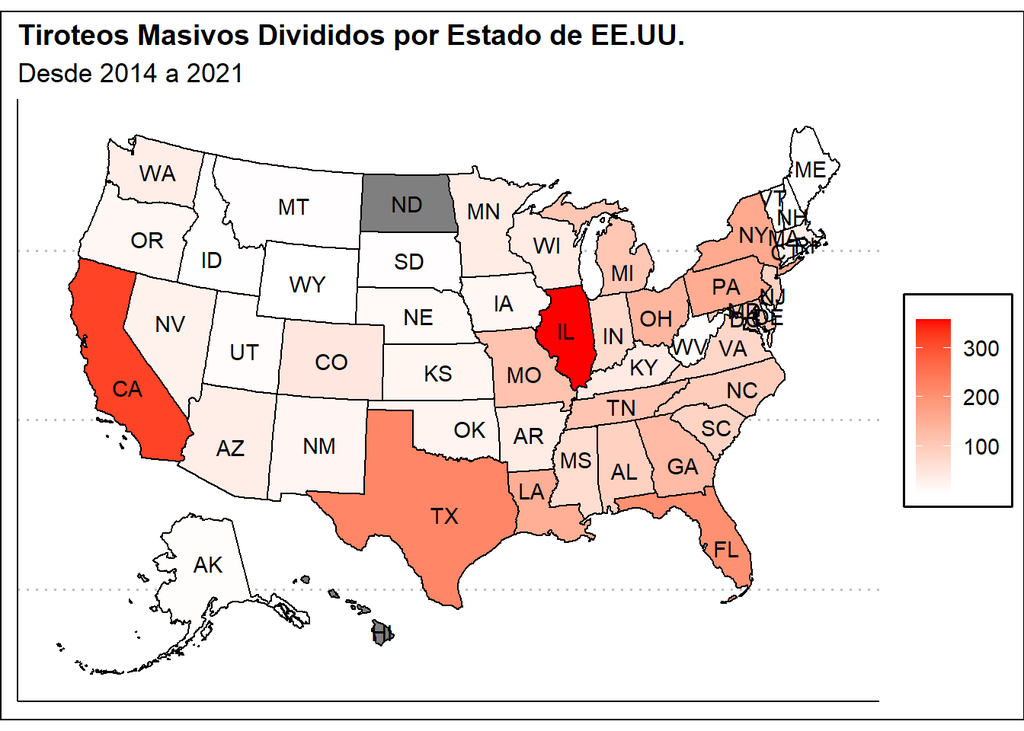

```r
proto_chart2 <- all_gva %>%
  group_by(State, fips, abbr) %>%
  summarise(Incident_Count = length(Incident_ID)) %>%
  ungroup()
chart2<-  plot_usmap( data = proto_chart2,
                      values = "Incident_Count",
                      labels = T) +
  scale_fill_gradient(low = "white",
                      high = "red",
                      name = NULL) +
  theme_clean()+
  theme(
        axis.text = element_blank(),
        axis.ticks = element_blank(),
        axis.title = element_blank(),
        axis.line = element_blank())+

  labs(title="Tiroteos Masivos Divididos por Estado de EE.UU.",
       subtitle = "Desde 2014 a 2021")




chart2
```

Además, hay que mantener en mente una de las principales razones por las que esta clase de eventos son tan traumaticos, la cual es el número de personas asesinadas o heridas en el proceso. Con respecto a esto, el siguiente histograma busca darnos una idea de como el se distribuye la variable número de tiroteos.

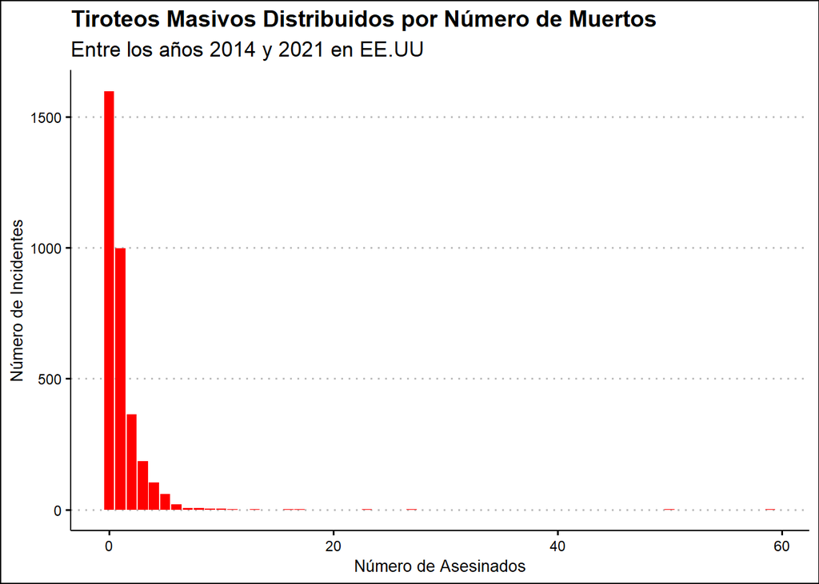

```r
chart3 <- all_gva %>%
  ggplot(aes(x = Killed)) +
  geom_bar(fill = "red")+
  theme_clean()+
  theme(legend.position = "none")+
  labs(title="Tiroteos Masivos Distribuidos por Número de Muertos",
       subtitle = "Entre los años 2014 y 2021 en EE.UU",
       x="Número de Asesinados", y = "Número de Incidentes")



chart3
```

Aunque esto es capaz de decirnos que gran cantidad de incidentes se acumulan a la izquierda del gráfico y que debe haber algún caso con cerca de 60 muertos, debemos acotar los ejes para poder tener una mejor fotografía del comportamiento de la variable número de asesinados. Es así, como el siguiente gráfico si nos revela con más seguridad que la grán cantidad de Tiroteos Masivos presenta menos de 10 asesinados.

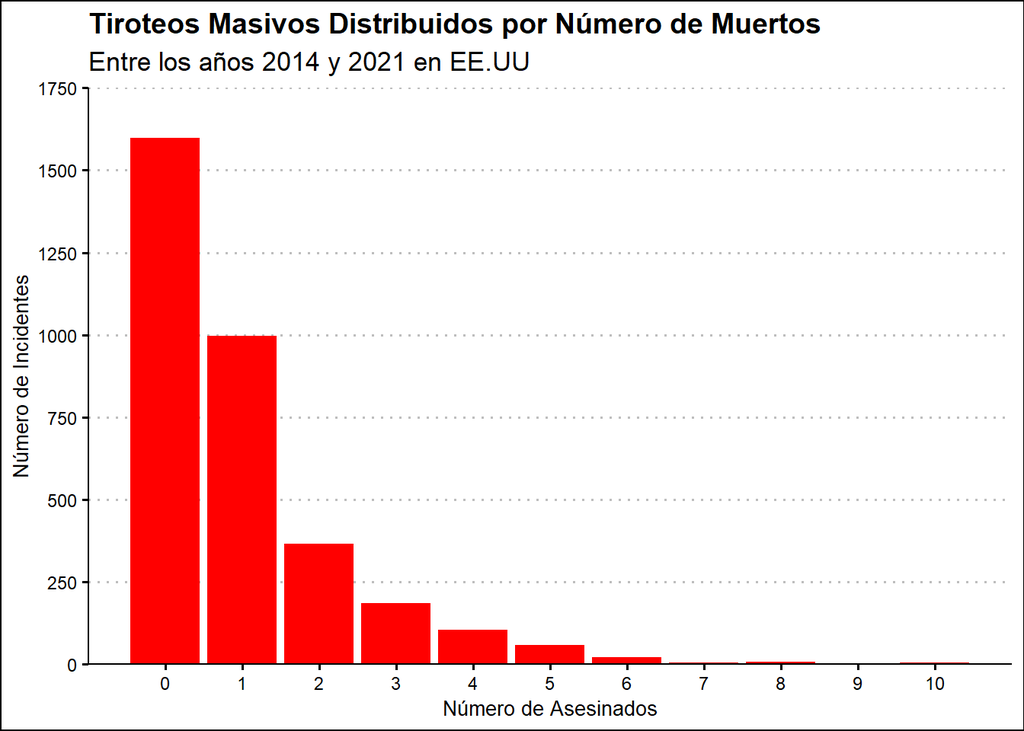

```r
chart4 <- chart3 +
  scale_x_continuous(limits = c(-1,11),
                     breaks = seq(0,10, by =1),
                     minor_breaks = NULL,
                     expand = c(0,0))+
  scale_y_continuous(limits = c(-0,1750),
                     breaks = seq(0,1750, by =250),
                     minor_breaks = NULL,
                     expand = c(0,0))

chart4
```

Se podría expandir si obtuvieramos una perspectiva relativa del comportamiento de la variable, algo que hace precisamente el siguiente gráfico, el que nos muestra que más del 45% de todos los tiroteos masivos terminan con 0 muertos, siendo el desenlace más común.

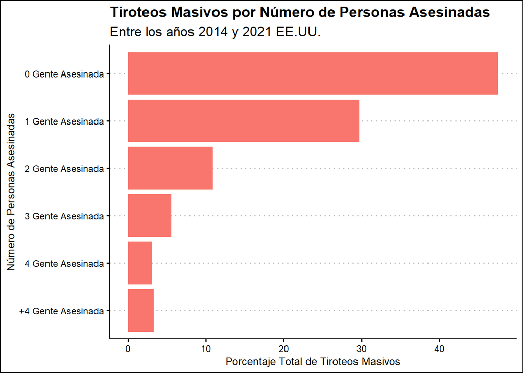

```r
chart5 <- all_gva %>%
  group_by(Killed) %>%
  summarise(Incident_Count = length(Incident_ID)) %>%
  mutate(Killed_Percentage = Incident_Count / sum(Incident_Count) *100,
         Killed = ifelse(Killed > 4,
                         yes = "+4",
                         no = Killed),
         Killed = paste(Killed, "Gente Asesinada", sep = " " ),
         Killed = fct_reorder(Killed, Killed_Percentage)) %>%
  ggplot() +
  geom_col(aes(
    x =Killed_Percentage,
    y =Killed,
    fill = "red")) +
  theme_clean() +
  theme(legend.position = "none")+
  labs(title="Tiroteos Masivos por Número de Personas Asesinadas",
       subtitle = "Entre los años 2014 y 2021 EE.UU.",
       x="Porcentaje Total de Tiroteos Masivos", y = "Número de Personas Asesinadas")


chart5
```

Pasamos por exactamente el mismo proceso para el numero de heridos, encontrando que cerca de 40% de todos los casos de Tiroteos Masivos tienen como caso más comun terminar con 4 heridos.

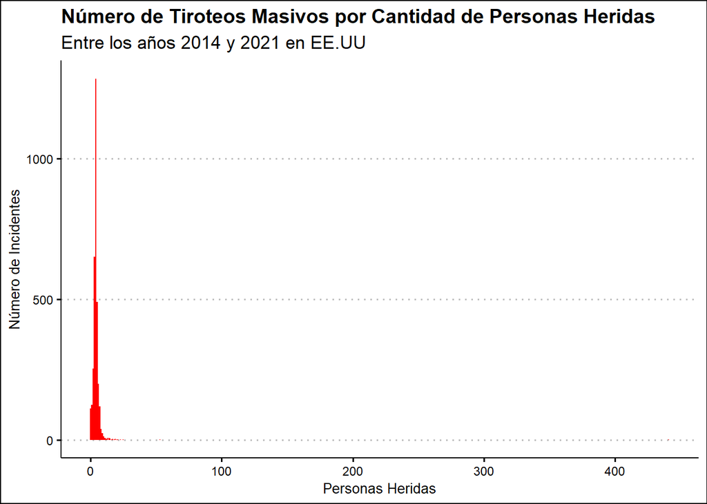

```r
chart6 <- all_gva %>%
  ggplot(aes(x = Injured)) +
  geom_bar(fill = "red")+
  theme_clean()+
  theme(legend.position = "none")+
  labs(title="Número de Tiroteos Masivos por Cantidad de Personas Heridas",
       subtitle = "Entre los años 2014 y 2021 en EE.UU",
       x="Personas Heridas", y = "Número de Incidentes")


chart6
```

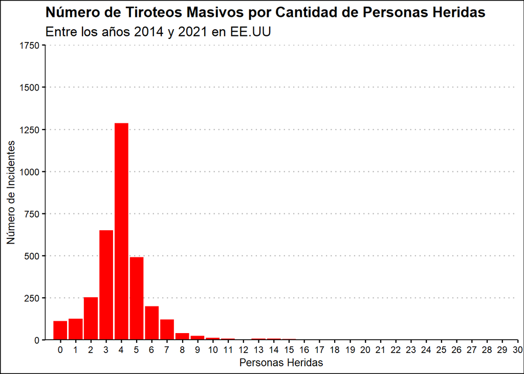

```r
chart7 <- chart6 +
  scale_x_continuous(limits = c(-1,30),
                     breaks = seq(0,30, by =1),
                     minor_breaks = NULL,
                     expand = c(0,0))+
  scale_y_continuous(limits = c(-0,1750),
                     breaks = seq(0,1750, by =250),
                     minor_breaks = NULL,
                     expand = c(0,0))

chart7
```

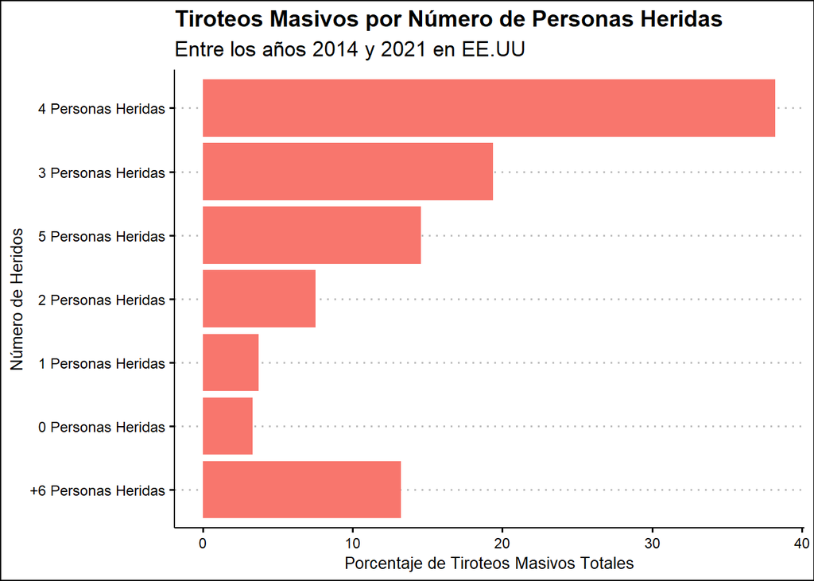

```r
chart8 <- all_gva %>%
  group_by(Injured) %>%
  summarise(Incident_Count = length(Incident_ID)) %>%
  mutate(Injured_Percentage = Incident_Count / sum(Incident_Count) *100,
         Injured = ifelse(Injured > 5,
                         yes = "+6",
                         no = Injured),
         Injured = paste(Injured, "Personas Heridas", sep = " " ),
         Injured = fct_reorder(Injured, Injured_Percentage)) %>%
  ggplot() +
  geom_col(aes(
    x = Injured_Percentage,
    y = Injured,
    fill = "red")) +
  theme_clean() +
  theme(legend.position = "none")+
  labs(title="Tiroteos Masivos por Número de Personas Heridas",
       subtitle = "Entre los años 2014 y 2021 en EE.UU",
       x="Porcentaje de Tiroteos Masivos Totales", y = "Número de Heridos")



chart8
```

En este siguiente gráfico nos permite apreciar las diferencias en la cantidad de Tiroteos Masivos entre los Estados que tienen fuerte y debil control de armas. Dejando ver que aquellos estados con mas libertad de portar armas tienen mas tiroteos al año.

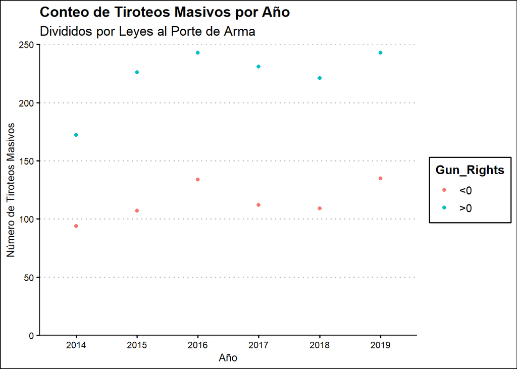

```r
chart9 <- consolidado %>%
  mutate(Gun_Rights = ifelse(Gun_Rights > 0,
                             yes = ">0",
                             no = "<0")) %>%
  group_by(Year, Gun_Rights) %>%
  summarise(Incident_Count = sum(Incident_Count)) %>%
  ggplot(aes(x = Year, y = Incident_Count, color = Gun_Rights)) +
  geom_point()+
  theme_clean()+
  scale_y_continuous(limits = c(0,250),
                     breaks = seq(0,250, by =50),
                     minor_breaks = NULL,
                     expand = c(0,0))+
  labs(title="Conteo de Tiroteos Masivos por Año",
       subtitle = "Divididos por Leyes al Porte de Arma",
       x="Año", y = "Número de Tiroteos Masivos")

chart9
```

## Regresión

El trabajo realiza 2 regresiones de data panel,la primera tiene como variable explicativa fundamental un indice que mide que tan restringido es el uso de de las armas en los diferentes estados. El segundo, es exactamente pero en lugar del indice de porte de armas, usamos porcentaje de suicidios cometidos con armas de fuego, el cual nos sirve de proxy para proporción de habitantes armados.

### Regresión por Indice que Mide Restricciones al Porte de Armas

```r
stargazer(grrandom ,  type = "text")
```

```
##
## ===================================================
##                             Dependent variable:
##                         ---------------------------
##                               Incident_Count
## ---------------------------------------------------
## Gun_Rights                        -37.991
##                                  (45.654)
##
## Median_Household_Income           0.0002
##                                  (0.0002)
##
## Over_All_Poverty                  1.035**
##                                   (0.434)
##
## Unemployment_Rate                -0.957***
##                                   (0.340)
##
## Constant                          -15.643
##                                  (15.082)
##
## ---------------------------------------------------
## Observations                        228
## R2                                 0.040
## Adjusted R2                        0.023
## F Statistic                      14.465***
## ===================================================
## Note:                   *p<0.1; **p<0.05; ***p<0.01
```

Lo que nos dice esta regresión es que aparentemente hay 2 variables que son lo suficientemente significantes las cuales son niveles de pobreza y desempleo, el resto de las variables no son suficientemente significativas, entre ellas el derecho a porte de armas que nosotros planteamos como centro del modelo.

### Regresión por Proporción de Habitantes Armados

```r
stargazer(frrandom ,  type = "text")
```

```
##
## ===================================================
##                             Dependent variable:
##                         ---------------------------
##                               Incident_Count
## ---------------------------------------------------
## firearm_Rate                      -0.016
##                                   (0.084)
##
## Median_Household_Income           0.0003*
##                                  (0.0002)
##
## Over_All_Poverty                  1.084**
##                                   (0.429)
##
## Unemployment_Rate                -0.867***
##                                   (0.327)
##
## Constant                          -19.531
##                                  (16.005)
##
## ---------------------------------------------------
## Observations                        228
## R2                                 0.038
## Adjusted R2                        0.020
## F Statistic                      13.702***
## ===================================================
## Note:                   *p<0.1; **p<0.05; ***p<0.01
```

Esta regresión basicamente nos comenta que las variables significativas son niveles de pobreza y desempleo. Al igual que el modelo anterior. De hecho, habla de una relación negativa entre número de Tiroteos y Desempleo, así como una relación positiva entre pobreza y Tiroteos.

# Conlusiones

Nuestro analísis de diferentes bases de datos, entre las que destaca una copilación de Tiroteos Masivos desarrollada por el Gun Violence Archive, que tenia como objetivo entender un poco más relación entre armas, leyes y tiroteos masivos, nos deja saber las siguientes conclusiones:

- En caso de que nuestro modelo sea correcto, pareciera que no hay evidencia empírica para decir que restricciones al porte de armas influyan en el número de Tiroteos Masivos.
- En caso de que nuestro modelo sea correcto, pareciera que no hay evidencia empríca para decir que la proporción de habitantes armandos tenga relación con el numero de Tiroteos Masivos.
- Para los últimos años del periodo 2014-2021 se puede notar un alza en el número de Tiroteos Masivos.
- Cerca de 45% de todos los Tiroteos Masivos tienen como desenlace 0 personas asesinadas y cerca de un 40% 4 personas heridas.
- Los Estados Ilinios, Texas, California y en general la región este de EE.UU. son el lugar en donde se concentran los Tiroteos Masivos. Por otro lado, la región del norte suele no presentar tantos, en especial los estados de Dakota del Norte y Hawai, para los cuales no hay registros de Tiroteos Masivos.

# Consideraciones y Limitaciones

En verdad dudamos que nuestras conclusiones de nuestro modelo sean consistentes con la realidad, esto puede deberse a que usamos bases de datos diferentes que a la del trabajo en el cual nos basamos y algunos errores al escoger la forma del modelo. De igual forma, la definición de Titoreos Masivos que nosotros usamos no es universalmete aceptada, es un concepto complejo que ha sido dificil de capturar en números.